# 用R畫存活曲線Survival curve

Yi-Ju Tseng

2020-05-13

因為研究需要，搜尋了用R畫存活曲線的方法，並調整了圖形參數以及將多張存活曲線圖合併排列，整理成此篇文章。

## 用R畫存活曲線所需套件

在R中有蠻多畫存活曲線相關的套件，我的初版程式是使用`ggfortify`套件，但後來Editor要求要在圖上加**Number at risk**的資訊，查了一下發現`ggfortify`套件沒有這個功能，又不想手動加，就重新搜尋了資源，找到一篇介紹`survminer`套件的[文章](http://www.sthda.com/english/wiki/ggfortify-extension-to-ggplot2-to-handle-some-popular-packages-r-software-and-data-visualization)，並完成完整的survival plot。

本介紹文以[survminer R package: Survival Data Analysis and Visualization](http://www.sthda.com/english/wiki/ggfortify-extension-to-ggplot2-to-handle-some-popular-packages-r-software-and-data-visualization)為基礎，並衍伸其他條件設定的教學。

以下介紹用`survminer`套件 ([官方說明文件](https://rpkgs.datanovia.com/survminer/index.html)) 畫存活曲線的步驟

首先載入`survminer`套件以及處理資料必須的`survival`套件 (需要套件中的`Surv()`函數)

```r
library(survival)
library(survminer)
```

## 範例資料

以`survival`套件內附的`lung`資料為例，資料包括:

(以下資料翻譯自`survival`套件說明文件)

- inst: 機構代碼
- time: 存活時間 (單位為日)
- status: “設限”或“事件發生”狀況，1為設限，2為事件發生，在此為死亡
  - 1=censored
  - 2=dead
- age: 年紀 (單位為年)
- sex: 性別
  - Male=1
  - Female=2
- ph.ecog: 醫生評估的ECOG體能狀況評估分數
  - 0= asymptomatic
  - 1= symptomatic but completely ambulatory
  - 2= in bed <50% of the day
  - 3= in bed > 50% of the day but not bedbound
  - 4= bedbound
- ph.karno: 醫生評估的Karnofsky體能狀況評估分數
  - bad=0-good=100
- pat.karno: 病人自己評估的Karnofsky體能狀況評估分數
- meal.cal: 卡路里攝取量
- wt.loss: 過去六個月體重下降多少

```r
knitr::kable(lung %>% head())
```

| inst | time | status | age | sex | ph.ecog | ph.karno | pat.karno | meal.cal | wt.loss |
| --- | --- | --- | --- | --- | --- | --- | --- | --- | --- |
| 3 | 306 | 2 | 74 | 1 | 1 | 90 | 100 | 1175 | NA |
| 3 | 455 | 2 | 68 | 1 | 0 | 90 | 90 | 1225 | 15 |
| 3 | 1010 | 1 | 56 | 1 | 0 | 90 | 90 | NA | 15 |
| 5 | 210 | 2 | 57 | 1 | 1 | 90 | 60 | 1150 | 11 |
| 1 | 883 | 2 | 60 | 1 | 0 | 100 | 90 | NA | 0 |
| 12 | 1022 | 1 | 74 | 1 | 1 | 50 | 80 | 513 | 0 |

## 基本存活曲線

在準備完資料後，可用`survfit()`函數製作存活模型，並以`ggsurvplot()`函數繪製存活曲線，`survfit()`函數的重要參數包括

- formula: `Surv(時間,設限或事件狀態)~分組依據`，在這個範例為`Surv(time,status)~分組依據`
- data: 資料名稱，在這個範例為lung

以最簡單的單一族群存活區限為例，想要畫這個資料集中**所有病人**的存活曲線，其實就是不分組的意思，可將**分組依據**設定成單一數字**1**，如下列範例

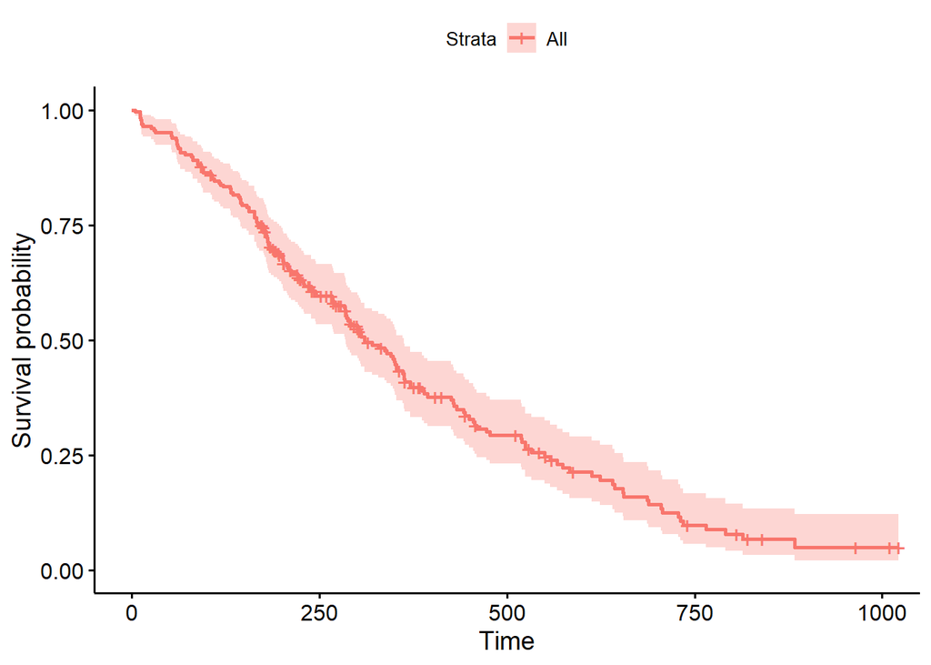

```r
fit<- survfit(Surv(time, status) ~ 1, data = lung)
ggsurvplot(fit)
```

以此類推，若想用性別做分組，也就是男生畫一條存活曲線，女生也畫一條，並放在同一張圖上，此時就將性別`sex`做為**分組依據**，如下範例

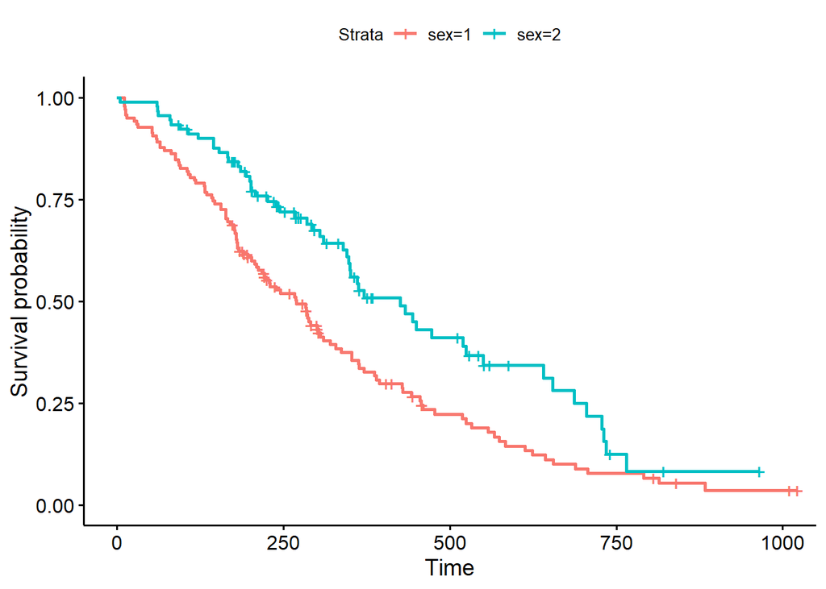

```r
fit<- survfit(Surv(time, status) ~ sex, data = lung)
ggsurvplot(fit)
```

## 增加P value

將`ggsurvplot()`函數的`pval`參數設定為`TRUE`，即可在圖中加上兩組檢定的P value，這個P value也可以用`surv_pvalue()`函數取得，預設的檢定方法為**log-rank test**，若想要修改，也可以透過設定`pval.method`參數修改。

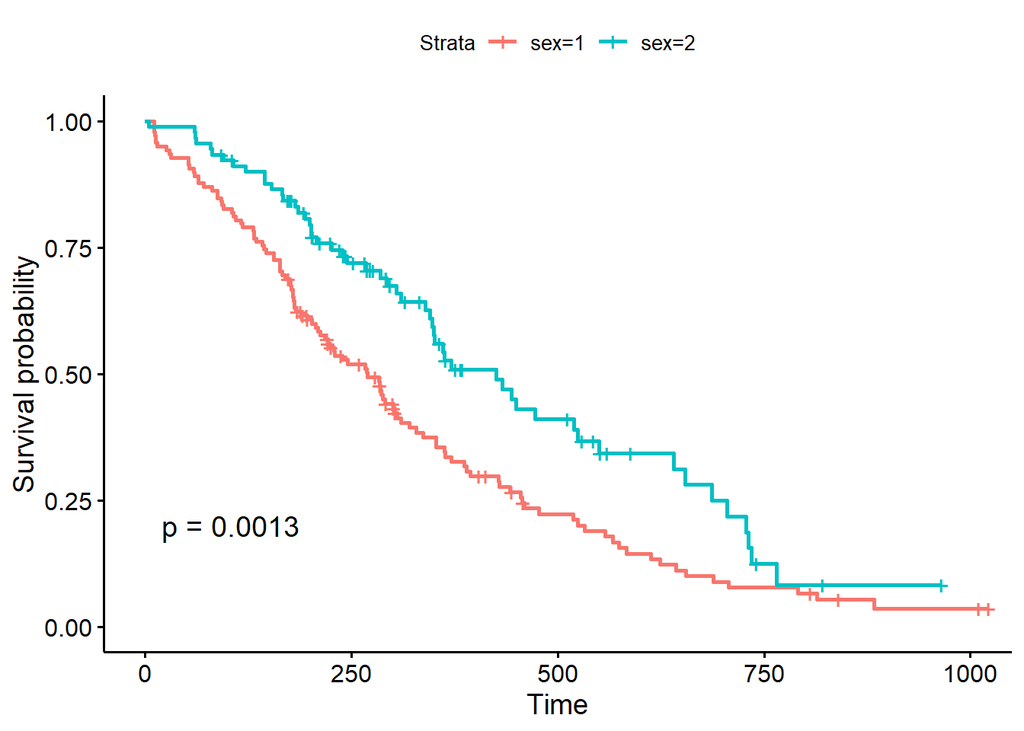

```r
ggsurvplot(fit, pval = TRUE)
```

可進一步用`pval.coord = c(100, 0.03)`調整P value顯示位置

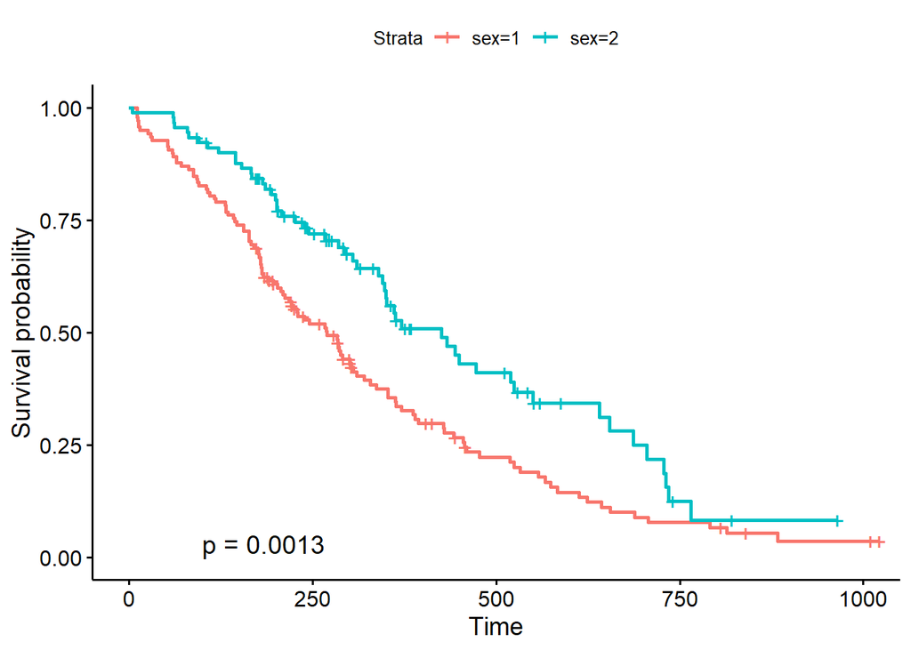

```r
ggsurvplot(fit, pval = TRUE, pval.coord = c(100, 0.03))
```

## 增加信賴區間

若生存曲線圖形要加上信賴區間的話，可設定`conf.int = TRUE`

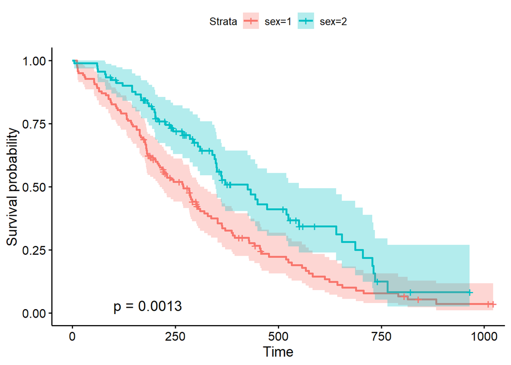

```r
ggsurvplot(fit, pval = TRUE, pval.coord = c(100, 0.03),
           conf.int = TRUE)
```

## 增加number of risk 表格

將`ggsurvplot()`函數的`risk.table`參數設定為`TRUE`，即可在圖中加上number of risk 表格

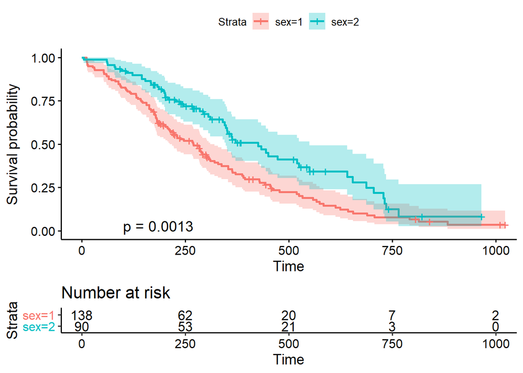

```r
ggsurvplot(fit, pval = TRUE, pval.coord = c(100, 0.03),
           conf.int = TRUE,
           risk.table = TRUE)
```

若不想要number of risk 表格Y軸文字的顏色，可將`risk.table.y.text.col`參數設成FALSE

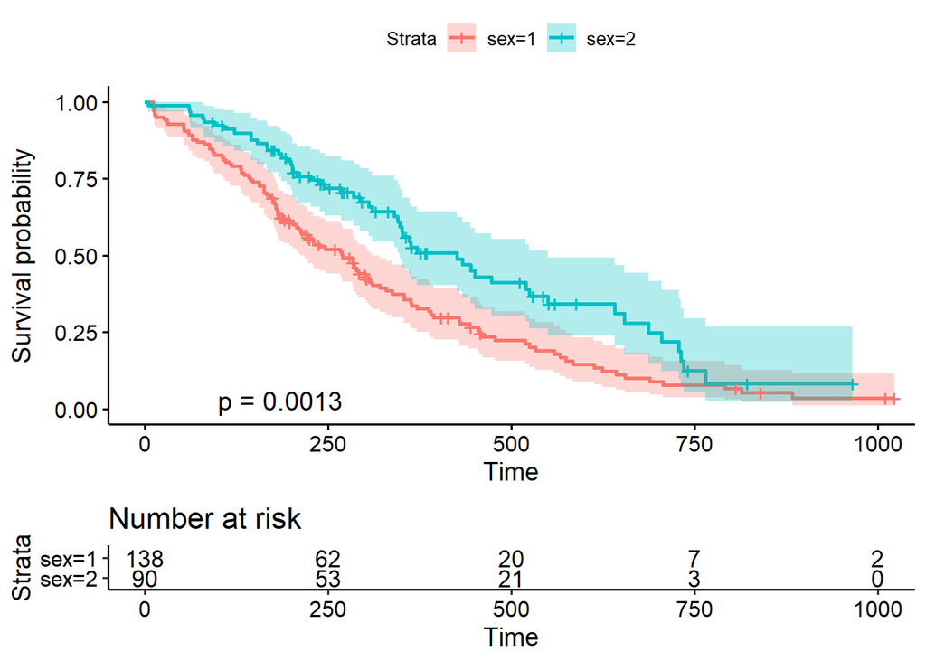

```r
ggsurvplot(fit, pval = TRUE, pval.coord = c(100, 0.03),
           conf.int = TRUE,
           risk.table = TRUE, risk.table.y.text.col = F)
```

## 格式微調

可分為存活曲線調整與number at risk表格調整，調整參數如下

- `font.main = 12` 圖表標題字型大小
- `font.x = 12` 圖表X軸字型大小
- `font.y = 12` 圖表Y軸字型大小
- `fontsize = 3` Number at risk內文字型大小
- `break.time.by = 100` 每100天設一個標記
- `font.tickslab = 10` 標記字型大小(100, 200, …等)
- `legend.labs = c("Men", "Women")` 將圖示文字改為Men或是Women
- `title="Format setting"` 加上圖形標題
- `xlab="", ylab=""` X軸Y軸標題設定
- `legend = "none"` 不要圖示
- `tables.theme = clean_theme()` 設定Number at risk表格樣式

若想改Number at risk表格的標題，只能用額外的程式碼`theme(plot.title = element_text(size = 10))`設定

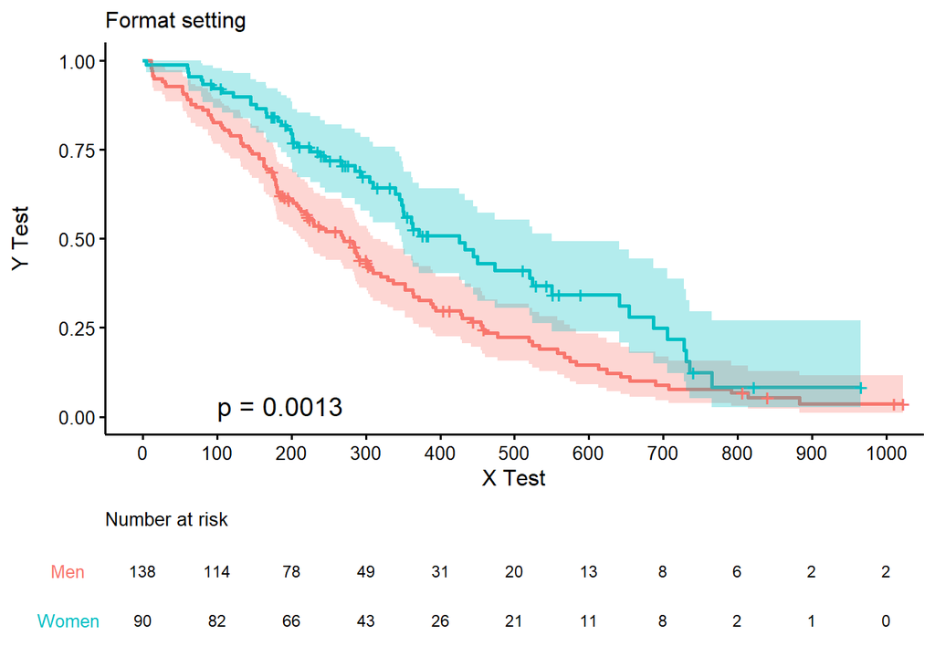

```r
res<-ggsurvplot(fit, pval = TRUE, pval.coord = c(100, 0.03),
                conf.int = TRUE,
                risk.table = TRUE,
                font.main = 12,
                font.x =  12,
                font.y = 12,
                font.tickslab = 10,
                fontsize = 3,
                break.time.by = 100,
                legend.labs = c("Men", "Women"),
                title="Format setting",
                xlab="X Test", ylab="Y Test", legend =  "none",
                tables.theme = clean_theme())
res$table <- res$table + theme(plot.title = element_text(size = 10))
res
```

## 客製化P value顯示方式

預設的P value是四位小數點，有時不太需要這麼多資訊，只需把小於0.01的值用**<0.01**來表示 (通常是<0.001才轉換，但這邊為了呈現效果改為<0.01)，那就需要在畫圖前先處理。這邊使用`surv_pvalue(fit)$pval`來取得P value `p`後，更進一步用`if else`來將數值轉成文字，最後在`ggsurvplot()`函數中，將`pval = p`參數設定為`p`，就能調整P value的顯示方法

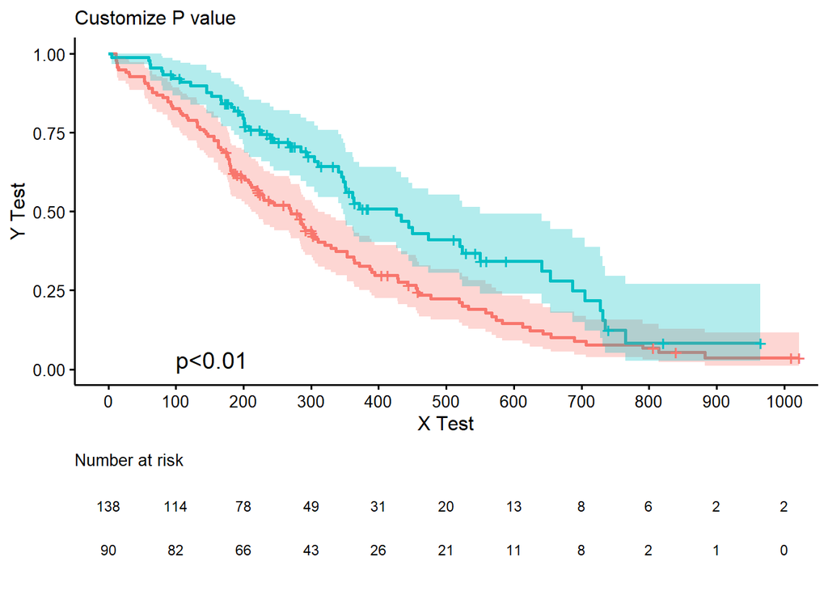

```r
p<-surv_pvalue(fit)$pval
if(p<0.01){
  p<-"p<0.01"
}else{
  p<-paste0("p=",round(p,3))
}

resP<-ggsurvplot(fit, pval = p, pval.coord = c(100, 0.03),
                 conf.int = TRUE,
                 risk.table = TRUE, risk.table.y.text.col = F,
                 font.main = 12,
                 font.x =  12,
                 font.y = 12,
                 font.tickslab = 10,
                 fontsize = 3,
                 break.time.by = 100,
                 legend.labs = c("Men", "Women"),
                 title="Customize P value",
                 xlab="X Test", ylab="Y Test", legend =  "none",
                 tables.theme = clean_theme())
resP$table <- resP$table + theme(plot.title = element_text(size = 10))
resP
```

## 合併多張存活曲線圖形

因`ggsurvplot()`畫出的圖形無法使用常見的`grid.arrange()`函數排序，`survminer`套件另有排列多圖的方法`arrange_ggsurvplots()`，使用方法是將多個`ggsurvplot`圖形放入`list`，作為`arrange_ggsurvplots()`的第一個參數，之後利用`ncol`設定Column數，`nrow`設定Row數，`risk.table.height`設定Number at risk表格高度

以下是橫放範例

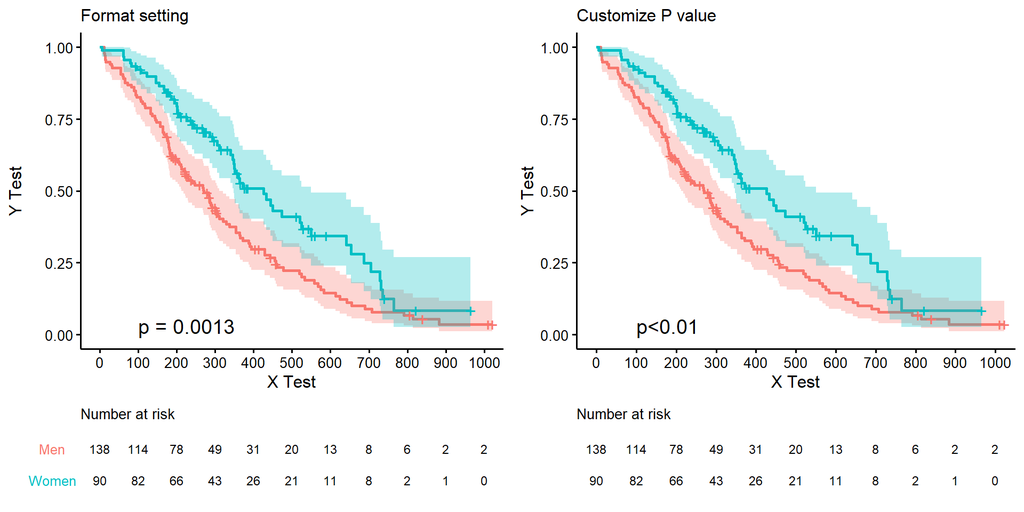

```r
arrange_ggsurvplots(list(res, resP),
                    ncol=2, nrow=1,
                    risk.table.height = 0.22)
```

直放範例

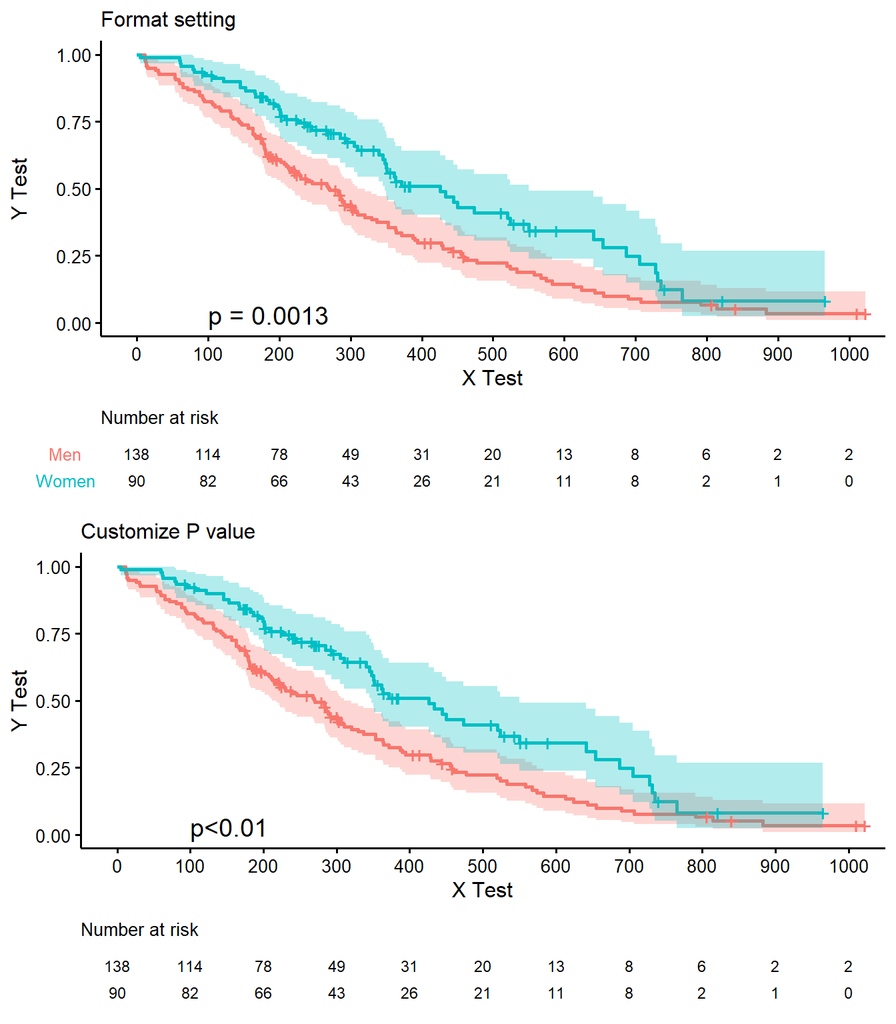

```r
arrange_ggsurvplots(list(res, resP),
                    ncol=1, nrow=2,
                    risk.table.height = 0.22)
```

## 參考資料

- [survminer R package: Survival Data Analysis and Visualization](http://www.sthda.com/english/wiki/ggfortify-extension-to-ggplot2-to-handle-some-popular-packages-r-software-and-data-visualization)
- [survminer套件官方說明文件](https://rpkgs.datanovia.com/survminer/index.html)